# Bayesian Analysis for Bike Sharing Prediction

Statistical Methods in Data Science and Laboratory II: Final Project

Aur Marina Iuliana, 1809715

2024-07-25

# Set Up

Bike sharing systems are of great interest today due to their important role in traffic, environmental and health issues. The dataset for this project, provided by [Kaggle](https://www.kaggle.com/datasets/imakash3011/rental-bike-sharing?select=hour.csv), focuses on analyzing **bike sharing trends** from 2011 to 2012.

The data includes information on time, weather conditions, and user type. The aim of this work is to identify the factors that influence the adoption, usage, and trends of bike sharing. This can guide **strategies** for optimizing bike sharing services, focusing marketing efforts, and enhancing the user experience.

The dataset is composed by **16 variables** and **731 observations (days)** with the following schema:

```
## Rows: 731
## Columns: 16
## $ instant    <int> 1, 2, 3, 4, 5, 6, 7, 8, 9, 10, 11, 12, 13, 14, 15, 16, 17, …
## $ dteday     <chr> "2011-01-01", "2011-01-02", "2011-01-03", "2011-01-04", "20…
## $ season     <int> 1, 1, 1, 1, 1, 1, 1, 1, 1, 1, 1, 1, 1, 1, 1, 1, 1, 1, 1, 1,…
## $ yr         <int> 0, 0, 0, 0, 0, 0, 0, 0, 0, 0, 0, 0, 0, 0, 0, 0, 0, 0, 0, 0,…
## $ mnth       <int> 1, 1, 1, 1, 1, 1, 1, 1, 1, 1, 1, 1, 1, 1, 1, 1, 1, 1, 1, 1,…
## $ holiday    <int> 0, 0, 0, 0, 0, 0, 0, 0, 0, 0, 0, 0, 0, 0, 0, 0, 1, 0, 0, 0,…
## $ weekday    <int> 6, 0, 1, 2, 3, 4, 5, 6, 0, 1, 2, 3, 4, 5, 6, 0, 1, 2, 3, 4,…
## $ workingday <int> 0, 0, 1, 1, 1, 1, 1, 0, 0, 1, 1, 1, 1, 1, 0, 0, 0, 1, 1, 1,…
## $ weathersit <int> 2, 2, 1, 1, 1, 1, 2, 2, 1, 1, 2, 1, 1, 1, 2, 1, 2, 2, 2, 2,…
## $ temp       <dbl> 0.3441670, 0.3634780, 0.1963640, 0.2000000, 0.2269570, 0.20…
## $ atemp      <dbl> 0.3636250, 0.3537390, 0.1894050, 0.2121220, 0.2292700, 0.23…
## $ hum        <dbl> 0.805833, 0.696087, 0.437273, 0.590435, 0.436957, 0.518261,…
## $ windspeed  <dbl> 0.1604460, 0.2485390, 0.2483090, 0.1602960, 0.1869000, 0.08…
## $ casual     <int> 331, 131, 120, 108, 82, 88, 148, 68, 54, 41, 43, 25, 38, 54…
## $ registered <int> 654, 670, 1229, 1454, 1518, 1518, 1362, 891, 768, 1280, 122…
## $ cnt        <int> 985, 801, 1349, 1562, 1600, 1606, 1510, 959, 822, 1321, 126…
```

Let us examine the dataser for any **duplicates** and **missing values**.

```
## Number of duplicates in the dataset:  0
```

```
## Number of missing values for each column:
```

```
##    instant     dteday     season         yr       mnth    holiday    weekday
##          0          0          0          0          0          0          0
## workingday weathersit       temp      atemp        hum  windspeed     casual
##          0          0          0          0          0          0          0
## registered        cnt
##          0          0
```

Here is a brief description of each column in the dataset:

- `instant`: record index, serving as a unique identifier for each row in the dataset.
- `dteday` : date of the bike rental in YYYY-MM-DD format.
- `season`: season of the year represented as an integer (1 for winter, 2 for spring, 3 for summer, 4 for fall).
- `yr`: year in which the data was recorded (0 for 2011, 1 for 2012).
- `mnth`: month of the year, indicated as an integer from 1 to 12.
- `holiday`: indicates whether the day is a holiday or not, based on the public holiday calendar.
- `weekday`: day of the week, represented as an integer from 0 to 6.
- `workingday`: indicates whether the day is a working day (1) or not (0).
- `weathersit`, weather situation for the day, represented as an integer:
  - 1: Clear, Few clouds, Partly cloudy.
  - 2: Mist + Cloudy, Mist + Broken clouds, Mist + Few clouds, Mist.
  - 3: Light Snow, Light Rain + Thunderstorm + Scattered clouds, Light Rain + Scattered clouds.
  - 4: Heavy Rain + Ice Pallets + Thunderstorm + Mist, Snow + Fog.
- `temp`: normalized temperature in Celsius, scaled between 0 and 1, with values divided by 41 (the maximum temperature).
- `atemp`: normalized feeling temperature (apparent temperature) of the day, scaled between 0 and 1, with values divided by 50 (the maximum apparent temperature).
- `hum`: normalized humidity of the day, scaled between 0 and 1, with values divided by 100 (the maximum humidity).
- `windspeed`: normalized wind speed of the day, scaled between 0 and 1, with values divided by 67 (the maximum wind speed).
- `casual`: number of casual users who rented bikes on the specific day.
- `registered`: number of registered users who rented bikes on the specific day.
- `cnt`: total count of bikes rented, which is the sum of casual and registered users for the specific day.

# Exploratory Data Analysis (EDA)

In common belief, the bike-sharing system is significantly influenced by **environmental** and **seasonal factors**, which can affect rental behavior. However, for a robust final prediction model, it is crucial to understand and quantify the impact of these factors.

Specifically, we need to analyze how variables (e.g., temperature, humidity, holidays, or workdays) relate to each other and **correlate with rental trends**.

## Qualitative Variables Analysis

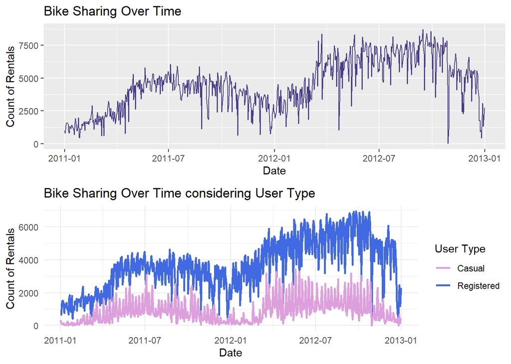

This plot displays the total count of bikes rented over time from the beginning of 2011 to the end of 2012. The data reveals a **clear seasonal trend**: bike rentals generally increase during the warmer months and decrease during the colder months, indicating higher bike usage during favorable weather conditions.

Additionally, the data from 2012 has **higher peaks** compared to 2011, indicating a possible increase in the popularity or availability of bike-sharing system. Both user types exhibit a similar trend to the top graph.

Let’s now analyze these insights more in detail.

Bike Rentals Count by Weather Situation

| Weather Situation | Total Bike Rentals | Percentage (%) |
| --- | --- | --- |
| 1 | 2257952 | 68.57 |
| 2 | 996858 | 30.27 |
| 3 | 37869 | 1.15 |

The data highlights that bike rentals are **heavily influenced by weather conditions**: as the weather conditions become less ideal, such as with mist or precipitation, the number of rentals decreases substantially.

Bike Rentals Count by Months

| Months | Total Bike Rentals | Percentage (%) |
| --- | --- | --- |
| 1 | 134933 | 4.10 |
| 2 | 151352 | 4.60 |
| 3 | 228920 | 6.95 |
| 4 | 269094 | 8.17 |
| 5 | 331686 | 10.07 |
| 6 | 346342 | 10.52 |
| 7 | 344948 | 10.48 |
| 8 | 351194 | 10.67 |
| 9 | 345991 | 10.51 |
| 10 | 322352 | 9.79 |
| 11 | 254831 | 7.74 |
| 12 | 211036 | 6.41 |

Bike Rentals Count by Seasons

| Seasons | Total Bike Rentals | Percentage (%) |
| --- | --- | --- |
| 1 | 471348 | 14.32 |
| 2 | 918589 | 27.90 |
| 3 | 1061129 | 32.23 |
| 4 | 841613 | 25.56 |

The data highlights that **summer** (season 3) is the most favored season for bike rentals, with **August** (month 8) showing the highest number of rentals. Conversely, rentals are lower during the **winter** (season 1), with **January** (month 1) recording the fewest rentals. This aligns with the seasonal pattern previously observed.

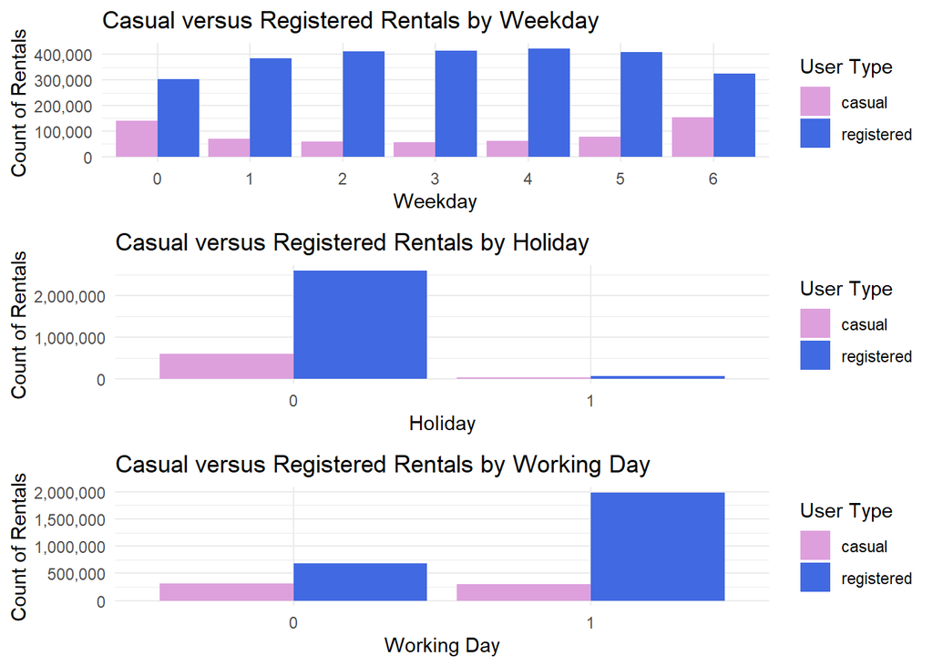

The rental counts for casual users tend to be higher towards the **end of the week**, with the highest values typically occurring around Saturday (weekday 6) and Sunday (weekday 0).

In contrast, the rental counts for registered users are generally higher **during the week** in the working days (label 1), reflecting a **routine use**.

During holidays (labels 1), bike rentals **drop significantly** for both user types, likely because people stay home or use their cars instead.

## Quantitative Variables Analysis

```
##       temp             atemp              hum           windspeed
##  Min.   :0.05913   Min.   :0.07907   Min.   :0.0000   Min.   :0.02239
##  1st Qu.:0.33708   1st Qu.:0.33784   1st Qu.:0.5200   1st Qu.:0.13495
##  Median :0.49833   Median :0.48673   Median :0.6267   Median :0.18097
##  Mean   :0.49538   Mean   :0.47435   Mean   :0.6279   Mean   :0.19049
##  3rd Qu.:0.65542   3rd Qu.:0.60860   3rd Qu.:0.7302   3rd Qu.:0.23321
##  Max.   :0.86167   Max.   :0.84090   Max.   :0.9725   Max.   :0.50746
##       cnt           casual         registered
##  Min.   :  22   Min.   :   2.0   Min.   :  20
##  1st Qu.:3152   1st Qu.: 315.5   1st Qu.:2497
##  Median :4548   Median : 713.0   Median :3662
##  Mean   :4504   Mean   : 848.2   Mean   :3656
##  3rd Qu.:5956   3rd Qu.:1096.0   3rd Qu.:4776
##  Max.   :8714   Max.   :3410.0   Max.   :6946
```

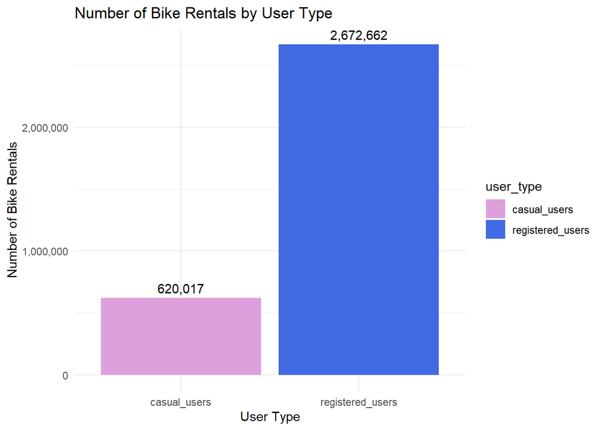

As noticed earlier, casual bike rentals are **much lower** than those of registered users, but they still impact the overall total count of bikes rentals. From this, we can assert that once registered, users tend to use bike rentals system **regularly**.

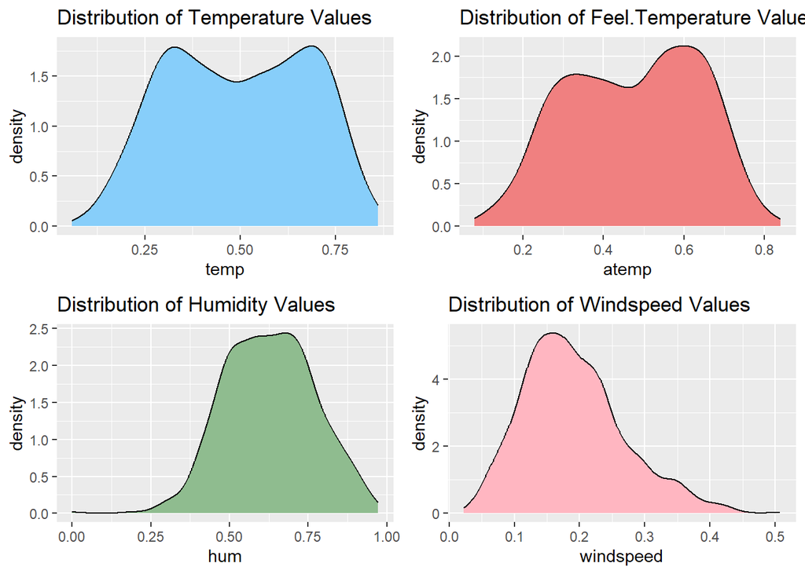

The quantitative variables `temp`, `atemp`, `hum`, and `windspeed` are evenly distributed and normalized. This ensures they are on **comparable scales**, simplifying interpretation and modeling.

# Outliers

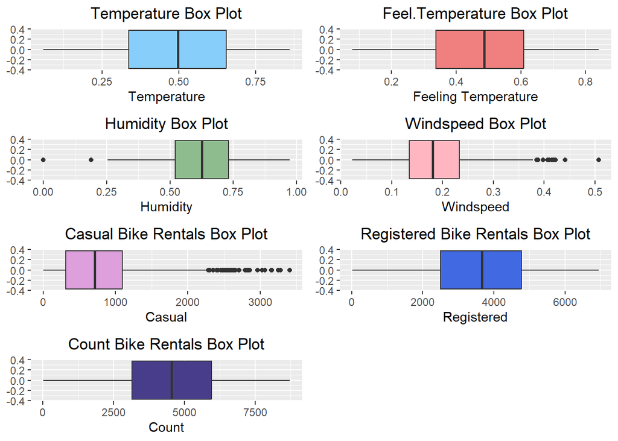

The outliers in the humidity (`hum`) and wind speed (`windspeed`) box plots reflect rare atmospheric conditions. They do not significantly impact the overall analysis and can represent **genuine seasonal variations**.

The outliers in the casual bike rentals (`casual`) box plot indicate days when the number of casual bike rentals is significantly higher than the average. It is preferable to keep them in the dataset as they represent **genuine fluctuations in bike rentals** due to factors like favorable weather conditions, special events, or promotions.

# Correlation Analysis

[interactive chart not shown]

Some positive correlations are quite evident:

- A **high positive correlation** (0.99) between `temp` and `atemp` variables is expected as they both measure aspects of temperature.
- A **high positive correlation** (0.95 and 0.67) between `cnt` and `registered/casual` variables reflects that total count of rentals is computed with both user types.
- A **high positive correlation** (0.89) between `mnth` and `season` variables is expected because they provide similar information about the time of year.

Other positive correlations are align with our previous observations:

- A **positive correlation** (0.59) between `weathersit` and `hum` variables indicates that higher humidity levels are associated with more adverse weather conditions (such as precipitation and mist).
- A **positive correlation** (0.63) between `cnt` with `temp`/`atemp` variables suggests that more rentals occur on warmer days/months.
- A **negative correlation** (-0.23) between `windspeed` and `cnt` variables indicates that higher wind speed levels discourage bike rentals.
- A **minimal negative effect** (-0.10) between`hum` and `cnt` variables means that humidity does not significantly influence bike rental trends.

# Distribution Analysis

Now, let us analyze the `cnt` variable in relation to the other quantitative variables by using scatter plots to visualize the **linear relationships** between them.

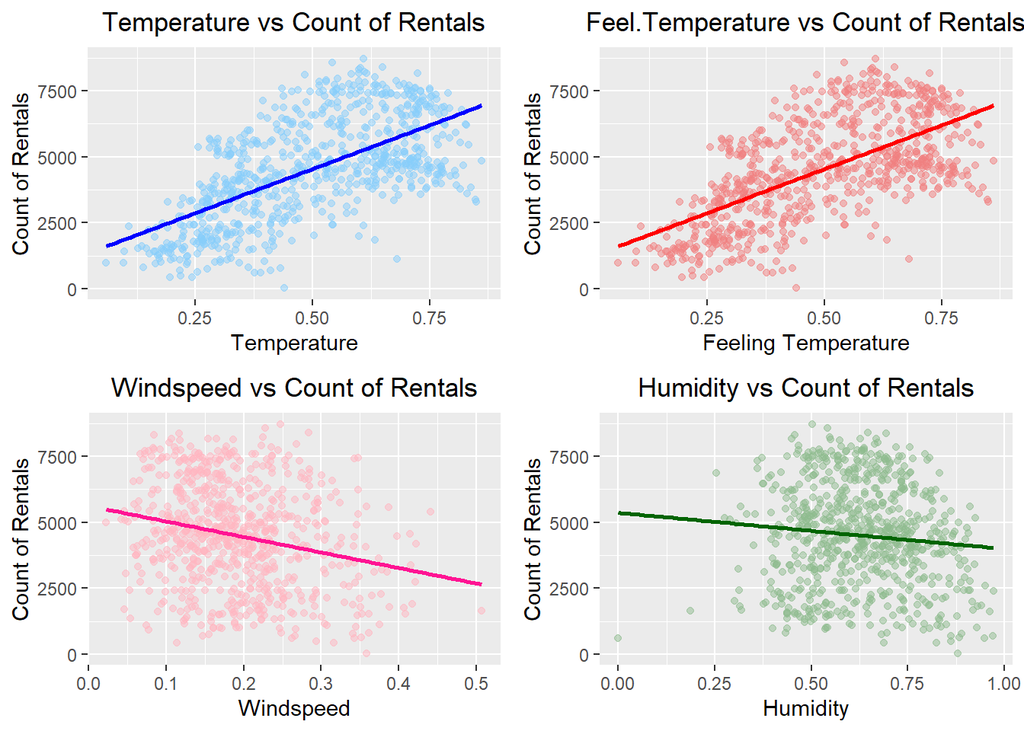

After observing the linear relationships, employing a **Linear Regression model** appears to be appropriate to predict bike rentals based on the environmental and seasonal settings.

However, a Linear Regression model might not capture more complex relationships in the data. For comparison purpose, the **Negative Binomial model** can be a suitable option when dealing with count data. This model generalizes the Poisson model by introducing an additional parameter to account for **overdispersion**, a phenomenon commonly observed in real-world data.

# Modelling

## Linear Regression

Linear Regression is a statistical model widely used to estimate the linear relationship between a continuous variable of interest $y$ (the response or dependent variable) on the basis of one or more other variables (the predictor or independent variables) $X$.

The model assumes a linear relationship, which can be represented mathematically as:

$$y = \beta^{T}X + \varepsilon$$

where:

- $y$ is the vector of observed dependent variables.
- $X$ represents the vector of predictors (independent variables or features).
- $\beta$ indicate the coefficient vector (weights).
- $\varepsilon \sim N(0, \sigma^2)$ represents the error term (or residual), representing the difference between the observed values and the values predicted by the model.

## Negative Binomial

Negative Binomial is a statistical model used to handle count data that exhibits overdispersion, which occurs when the variance of the data is significantly greater than the mean.

We assume that the count data $Y_i$ follows a Negative Binomial distribution with parameter $p_i$, which represents the probability of “success” in a single trial of the Bernoulli distribution, and the dispersion parameter $size$:

$$Y_i \mid p_i, size \sim \text{NegBin}(p_i, size)$$
$$p_i = \frac{size}{size + \lambda_i}$$

To relate the mean $\lambda_i$ to the predictors, we use a **log link function**. The link function connects the mean of the distribution to a linear predictor:

$$\log(\lambda_i) = \mathbf{X}_i \boldsymbol{\beta}$$

## Multicollinearity

Including highly correlated variables in the model may lead to redundancy, which can cause **multicollinearity**<sup>1</sup>. This situation makes complicate to distinguish the individual effect of each variable on the response $y$ due to their overlapping information, making the model’s estimates less reliable.

The correlation matrix already indicates potential multicollinearity issues. In the following steps, we will further investigate its presence in the data.

# Frequentist Analysis

The Frequentist analysis assumes that the model parameters (e.g., coefficients) are fixed but unknown constants. In our scenario, the goal is to provide comprehensive **statistical insights** into how various factors affect the count of bike rentals. This approach ensures that the model remains statistically valid.

## First Model: Linear Regression

We will define the model with all the variables and check for the presence of multicollinearity using the **Variance Inflation Factor (VIF)**. VIF measures the ratio of the variance of a parameter estimate in a full model (including all other parameters) to the variance of the parameter estimate if the model includes only that single parameter.

```r
# Define the model with all the variables
model_lm_1 = lm(cnt ~ season + yr + mnth + holiday + weekday + workingday + weathersit
          + temp + atemp + hum + windspeed + casual + registered, data = bike_data)
```

```
## Variance Inflation Factors (VIF):
```

```
##     season         yr       mnth    holiday    weekday workingday weathersit
##   4.104348   2.742865   3.360293   1.098107   1.051268   3.111266   1.914898
##       temp      atemp        hum  windspeed     casual registered
##  63.650194  64.806018   1.948368   1.252354   3.532670   5.993440
```

We can observe that **some VIFs values are very high**, indicating the presence of multicollinearity. Consequently, for the modelling phase, we will use only the `temp` variable to represent temperature, the `cnt` variable to represent the number of bike rentals, while excluding the variables for feeling temperature (atemp) and user types (casual and registered).

```r
# Define the model without redundant variables
model_lm_2 = lm(cnt ~ season + yr + mnth + holiday + weekday + workingday + weathersit
          + temp + hum + windspeed, data = bike_data)
```

```
## Variance Inflation Factors (VIF) after removing redudant variables:
```

```
##     season         yr       mnth    holiday    weekday workingday weathersit
##   3.541429   1.020251   3.332130   1.081437   1.021463   1.076338   1.741541
##       temp        hum  windspeed
##   1.215589   1.905040   1.165206
```

The model no longer exhibits signs of multicollinearity, as none of the VIF values exceed the threshold of 4. This indicates that the model coefficients are likely to be **stable** and **reliable**.

To analyze the results of the Linear Regression analysis, including estimates for each of the beta coefficients, we will use the `summary()` function and generate several plots.

```
##
## Call:
## lm(formula = cnt ~ season + yr + mnth + holiday + weekday + workingday +
##     weathersit + temp + hum + windspeed, data = bike_data)
##
## Residuals:
##     Min      1Q  Median      3Q     Max
## -4072.3  -440.0    34.9   551.7  2992.4
##
## Coefficients:
##             Estimate Std. Error t value Pr(>|t|)
## (Intercept)  1626.11     230.47   7.055 4.05e-12 ***
## season        515.24      54.86   9.392  < 2e-16 ***
## yr           2040.88      65.37  31.221  < 2e-16 ***
## mnth          -39.81      17.12  -2.325  0.02037 *
## holiday      -536.84     201.45  -2.665  0.00787 **
## weekday        67.21      16.32   4.117 4.28e-05 ***
## workingday    119.21      72.21   1.651  0.09919 .
## weathersit   -622.29      78.42  -7.935 8.05e-15 ***
## temp         5154.22     195.03  26.428  < 2e-16 ***
## hum          -960.15     313.79  -3.060  0.00230 **
## windspeed   -2730.42     451.02  -6.054 2.27e-09 ***
## ---
## Signif. codes:  0 '***' 0.001 '**' 0.01 '*' 0.05 '.' 0.1 ' ' 1
##
## Residual standard error: 874.9 on 720 degrees of freedom
## Multiple R-squared:  0.7988, Adjusted R-squared:  0.796
## F-statistic: 285.9 on 10 and 720 DF,  p-value: < 2.2e-16
```

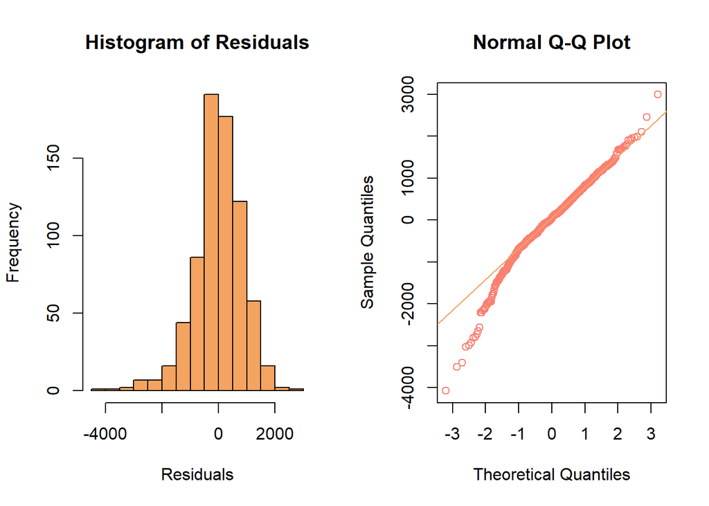

```
## Linear Regression Model AIC:  11991.1
```

Working Day (`workingday`) p-value of 0.09919 indicates that it is **not statistically significant**, suggesting that the variable might not be necessary for the model. However, removing this variable led to a slight increase of residual standard error, indicating that it likely captures significant aspects in the model.

Some considerations regarding the metrics:

- The **Residual Standard Error (RSE) at 874.9** reflects the average amount by which the actual counts deviate from the predicted, indicating overall good performance of the model.
- The **Multiple R-squared at 0.798** suggests that 79,8% of the variance in the dependent variable is explained by the model, indicating a strong fit of the model to the data.
- **Adjusted R-squared value at 0.796**, which closely approximates the R-squared value, reflects that the model uses an appropriate number of predictors.
- The **F-statistic value at 285.9** and the p-value < 2.2e-16 indicate that the model is statistically significant.

Some considerations regarding the plots:

- The histogram of Residuals shows residuals centered around zero and distributed symmetrically, suggesting that they are are **normally distributed**.
- The Normal Q-Q plot confirms this trend but highlights deviations at the extremes, indicating the presence of some **outliers**.

## Second Model: Negative Binomial

```r
model_nb = glm.nb(cnt ~ season + yr + mnth + holiday + weekday + workingday + weathersit
                  + temp + hum + windspeed, data = bike_data)
```

To analyze the results of the Negative Binomial analysis, including estimates for each of the beta coefficients, we will use the `summary()` function and generate several plots.

```
##
## Call:
## glm.nb(formula = cnt ~ season + yr + mnth + holiday + weekday +
##     workingday + weathersit + temp + hum + windspeed, data = bike_data,
##     init.theta = 13.52901384, link = log)
##
## Deviance Residuals:
##      Min        1Q    Median        3Q       Max
## -10.2469   -0.5407    0.0798    0.5030    2.5860
##
## Coefficients:
##              Estimate Std. Error z value Pr(>|z|)
## (Intercept)  7.486365   0.071784 104.290  < 2e-16 ***
## season       0.152638   0.017091   8.931  < 2e-16 ***
## yr           0.488981   0.020351  24.028  < 2e-16 ***
## mnth        -0.009481   0.005336  -1.777  0.07560 .
## holiday     -0.167823   0.062745  -2.675  0.00748 **
## weekday      0.013512   0.005082   2.659  0.00784 **
## workingday   0.039642   0.022481   1.763  0.07784 .
## weathersit  -0.174254   0.024420  -7.136 9.64e-13 ***
## temp         1.461361   0.060716  24.069  < 2e-16 ***
## hum         -0.227532   0.097711  -2.329  0.01988 *
## windspeed   -0.679881   0.140441  -4.841 1.29e-06 ***
## ---
## Signif. codes:  0 '***' 0.001 '**' 0.01 '*' 0.05 '.' 0.1 ' ' 1
##
## (Dispersion parameter for Negative Binomial(13.529) family taken to be 1)
##
##     Null deviance: 2542.75  on 730  degrees of freedom
## Residual deviance:  746.17  on 720  degrees of freedom
## AIC: 12332
##
## Number of Fisher Scoring iterations: 1
##
##
##               Theta:  13.529
##           Std. Err.:  0.707
##
##  2 x log-likelihood:  -12308.240
```

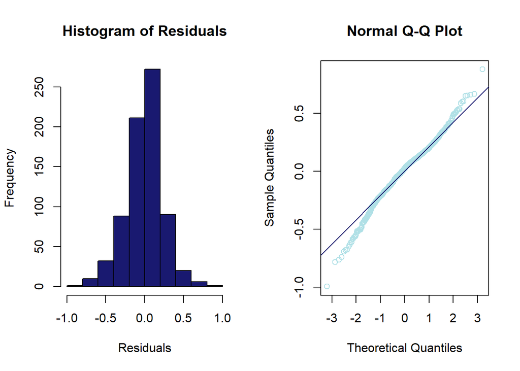

In the Negative Binomial model, the variables month (`mnth`) and working day (`workingday`) are classified as **not statistically significant** for the final prediction. However, similar to the Linear Regression model, their removal led to a slight increase in the error, indicating that they likely capture significant aspects of the data.

## Models Comparison

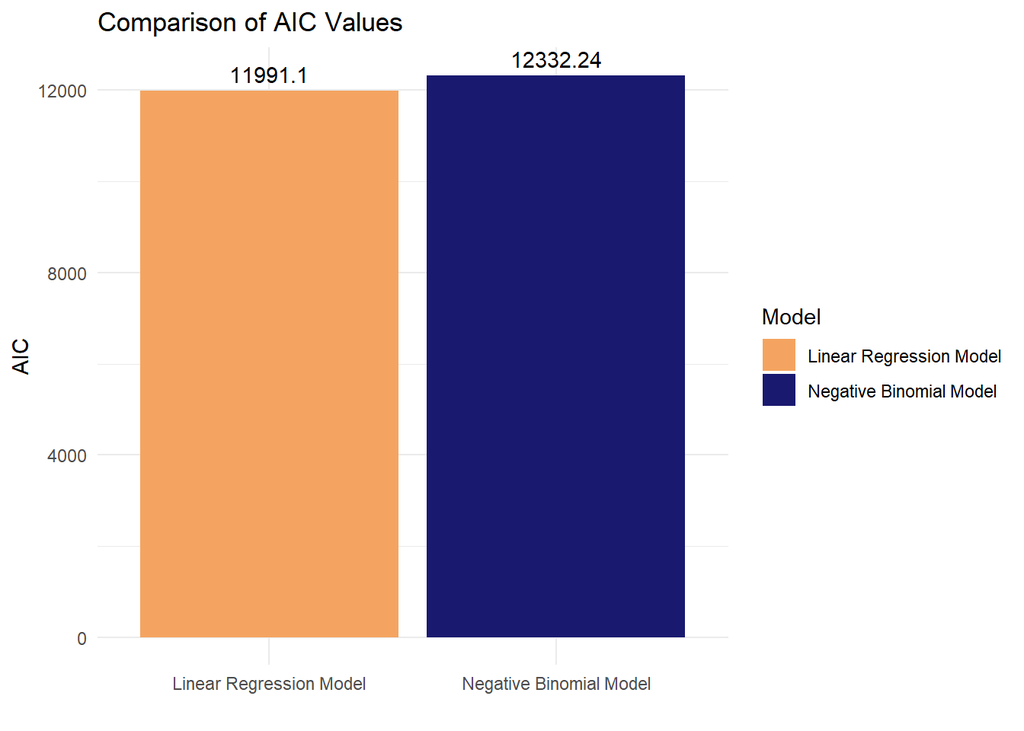

# Bayesian Analysis

In contrast to Frequentist analysis, Bayesian analysis treats the model parameters as **random variables with associated probability distributions**.

This approach allows for the integration of prior knowledge or beliefs about the parameters in the model, which can be updated with new data to form a posterior distribution. The goal of this approach is to identify the **posterior distribution of parameters** (e.g., coefficients) based on the prior probability distribution and the observed data.

Choosing the appropriate prior depends on how much prior information we have and how much influence we want the prior to have on our posterior distribution.

## First Model: Linear Regression

```r
# Set a seed for reproducibility
set.seed(123)

# Define the model for the Bayesian analysis
lm_bayesian_model <- function(){
  # Compute the Likelihood
  for (i in 1:N){
    y[i] ~ dnorm(mu[i], tau)
    mu[i] <- alpha + beta_season * season[i] +
            beta_year * yr[i] +
            beta_holiday * holiday[i] +
            beta_weekday * weekday[i] +
            beta_workingday * workingday[i] +
            beta_weathersit * weathersit[i] +
            beta_temp * temp[i] +
            beta_hum * hum[i] +
            beta_windspeed * windspeed[i]
    }

  # Define the priors for the intercept alpha and the regression coefficients
  alpha ~ dnorm(0, 1.0e-6)
  beta_season ~ dnorm(0, 1.0e-6)
  beta_year ~ dnorm(0, 1.0e-6)
  beta_holiday ~ dnorm(0, 1.0e-6)
  beta_weekday ~ dnorm(0, 1.0e-6)
  beta_workingday ~ dnorm(0, 1.0e-6)
  beta_weathersit ~ dnorm(0, 1.0e-6)
  beta_temp ~ dnorm(0, 1.0e-6)
  beta_hum ~ dnorm(0, 1.0e-6)
  beta_windspeed ~ dnorm(0, 1.0e-6)

  # Define sigma and the priors for the variable tau
  tau ~ dgamma(0.01, 0.01)
  sigma = 1/sqrt(tau)
}
```

```r
# Define Features
y <- as.numeric(bike_data$cnt)
season <- as.numeric(bike_data$season)
yr <- as.numeric(bike_data$yr)
holiday <- as.numeric(bike_data$holiday)
weekday <- as.numeric(bike_data$weekday)
workingday <- as.numeric(bike_data$workingday)
weathersit <- as.numeric(bike_data$weathersit)
temp <- as.numeric(bike_data$temp)
hum <- as.numeric(bike_data$hum)
windspeed <- as.numeric(bike_data$windspeed)

# Set parameters to save
model_params_lm <- c("beta_season", "beta_year", "beta_holiday", "beta_weekday",
                "beta_workingday", "beta_weathersit", "beta_temp", "beta_hum",
                "beta_windspeed")

# Prepare the data for RJags
data_jags_lm <- list("y" = y,
                     "N" = nrow(bike_data),
                     "season" = season,
                     "yr" = yr,
                     "holiday" = holiday,
                     "weekday" = weekday,
                     "workingday" = workingday,
                     "weathersit" = weathersit,
                     "temp" = temp,
                     "hum" = hum,
                     "windspeed" = windspeed
                    )
```

```r
# Fit the mode using RJags
lm_model_jags <- jags(data = data_jags_lm,
                   parameters.to.save = model_params_lm,
                   model.file = lm_bayesian_model,
                   n.chains = 3,
                   n.iter = 10000,
                   n.burnin = 1000
                  )
```

```
## module glm loaded
```

```r
lm_model_jags
```

```
## Inference for Bugs model at "C:/Users/Marina/AppData/Local/Temp/RtmpCOKV9d/model1ed47a3d4e8", fit using jags,
##  3 chains, each with 10000 iterations (first 1000 discarded), n.thin = 9
##  n.sims = 3000 iterations saved
##                   mu.vect sd.vect      2.5%       25%       50%       75%
## beta_holiday     -525.841 200.375  -918.002  -659.997  -526.880  -391.525
## beta_hum         -759.550 295.835 -1343.315  -961.992  -765.073  -553.250
## beta_season       425.015  32.009   363.716   402.699   424.558   446.508
## beta_temp        5037.238 185.850  4676.462  4916.173  5038.124  5161.485
## beta_weathersit  -661.138  77.897  -809.969  -714.017  -660.236  -610.054
## beta_weekday       68.150  16.310    36.449    57.171    68.200    79.129
## beta_windspeed  -2165.779 407.957 -2998.043 -2439.595 -2167.093 -1895.363
## beta_workingday   133.931  71.221   -11.430    87.143   135.047   181.316
## beta_year        2041.955  65.523  1917.198  1998.047  2040.816  2086.160
## deviance        11985.775   5.421 11977.327 11981.832 11985.152 11988.893
##                     97.5%  Rhat n.eff
## beta_holiday     -131.680 1.001  2700
## beta_hum         -175.834 1.002  1700
## beta_season       487.026 1.001  3000
## beta_temp        5403.710 1.001  3000
## beta_weathersit  -509.039 1.001  3000
## beta_weekday       99.683 1.003   820
## beta_windspeed  -1344.969 1.001  2500
## beta_workingday   273.835 1.001  3000
## beta_year        2172.963 1.001  3000
## deviance        11998.137 1.001  3000
##
## For each parameter, n.eff is a crude measure of effective sample size,
## and Rhat is the potential scale reduction factor (at convergence, Rhat=1).
##
## DIC info (using the rule, pD = var(deviance)/2)
## pD = 14.7 and DIC = 12000.5
## DIC is an estimate of expected predictive error (lower deviance is better).
```

## Second Model: Negative Binomial

```r
# Set a seed for reproducibility
set.seed(123)

# Define the Negative Binomial model for the Bayesian analysis
nb_bayesian_model <- function(){
  # Compute the Likelihood
  for (i in 1:N){
    y[i] ~ dnegbin(p[i], size)
    p[i] <- size / (size + lambda[i])
    log(lambda[i]) <- alpha + beta_season * season[i] +
                 beta_year * yr[i] +
                 beta_holiday * holiday[i] +
                 beta_weekday * weekday[i] +
                 beta_workingday * workingday[i] +
                 beta_weathersit * weathersit[i] +
                 beta_temp * temp[i] +
                 beta_hum * hum[i] +
                 beta_windspeed * windspeed[i]

  }

  # Define the priors for the intercept alpha and the coefficients
  alpha ~ dnorm(0, 1.0e-6)
  beta_season ~ dnorm(0, 1.0e-6)
  beta_year ~ dnorm(0, 1.0e-6)
  beta_holiday ~ dnorm(0, 1.0e-6)
  beta_weekday ~ dnorm(0, 1.0e-6)
  beta_workingday ~ dnorm(0, 1.0e-6)
  beta_weathersit ~ dnorm(0, 1.0e-6)
  beta_temp ~ dnorm(0, 1.0e-6)
  beta_hum ~ dnorm(0, 1.0e-6)
  beta_windspeed ~ dnorm(0, 1.0e-6)
  size ~ dunif(0.001, 1000)
  }
```

```r
# Set parameters to save
model_params_nb <- c("beta_season", "beta_year", "beta_holiday", "beta_weekday",
                "beta_workingday", "beta_weathersit", "beta_temp", "beta_hum",
                "beta_windspeed")

# Prepare the data for RJags
data_jags_nb <- list("y" = y,
                  "N" = nrow(bike_data),
                  "season" = season,
                  "yr" = yr,
                  "holiday" = holiday,
                  "weekday" = weekday,
                  "workingday" = workingday,
                  "weathersit" = weathersit,
                  "temp" = temp,
                  "hum" = hum,
                  "windspeed" = windspeed
                  )
```

```r
# Fit the mode using RJags
nb_model_jags <- jags(data = data_jags_nb,
                   parameters.to.save = model_params_nb,
                   model.file = nb_bayesian_model,
                   n.chains = 3,
                   n.iter = 10000,
                   n.burnin = 1000
                  )
nb_model_jags
```

```
## Inference for Bugs model at "C:/Users/Marina/AppData/Local/Temp/RtmpCOKV9d/model1ed43ba83ca7", fit using jags,
##  3 chains, each with 10000 iterations (first 1000 discarded), n.thin = 9
##  n.sims = 3000 iterations saved
##                   mu.vect sd.vect      2.5%       25%       50%       75%
## beta_holiday       -0.169   0.062    -0.289    -0.211    -0.169    -0.126
## beta_hum           -0.238   0.103    -0.440    -0.305    -0.237    -0.171
## beta_season         0.127   0.010     0.108     0.121     0.127     0.134
## beta_temp           1.471   0.065     1.344     1.427     1.469     1.514
## beta_weathersit    -0.174   0.025    -0.223    -0.191    -0.174    -0.157
## beta_weekday        0.013   0.005     0.003     0.010     0.013     0.017
## beta_windspeed     -0.674   0.145    -0.956    -0.771    -0.674    -0.579
## beta_workingday     0.039   0.023    -0.006     0.024     0.039     0.054
## beta_year           0.490   0.020     0.450     0.476     0.490     0.504
## deviance        12322.193   4.800 12314.814 12318.784 12321.567 12325.011
##                     97.5%  Rhat n.eff
## beta_holiday       -0.048 1.001  2900
## beta_hum           -0.043 1.005   530
## beta_season         0.146 1.002  1200
## beta_temp           1.599 1.001  3000
## beta_weathersit    -0.124 1.005   510
## beta_weekday        0.023 1.001  3000
## beta_windspeed     -0.386 1.002  1400
## beta_workingday     0.085 1.002  1200
## beta_year           0.530 1.001  3000
## deviance        12333.290 1.003   980
##
## For each parameter, n.eff is a crude measure of effective sample size,
## and Rhat is the potential scale reduction factor (at convergence, Rhat=1).
##
## DIC info (using the rule, pD = var(deviance)/2)
## pD = 11.5 and DIC = 12333.7
## DIC is an estimate of expected predictive error (lower deviance is better).
```

## Bayesian Results

The results are consistent with those from the Frequentist analysis: in both models, **temperature** (`temp`) is identified as the most significant factor affecting positively the number of bike rentals, while **wind speed** (`windspeed`) is recognized as the primary factor reducing them.

## Models Comparison

The **Deviance Information Criterion (DIC)** is a criterion used for model selection in Bayesian Analysis. It aims to balance the **quality of fit** of the model with its **complexity**, helping to avoid overfitting.

The DIC value can be computed with the following general formula:

$$D(\overline{\theta}) = - 2 \cdot \text{log-likelihood of the model}$$

$p_D$ is the **penalty term for model complexity** and is calculated as follows:

$$p_D = \frac{1}{2} \cdot var[D(\theta)]$$

Let’s now compare the DIC values for the two models.

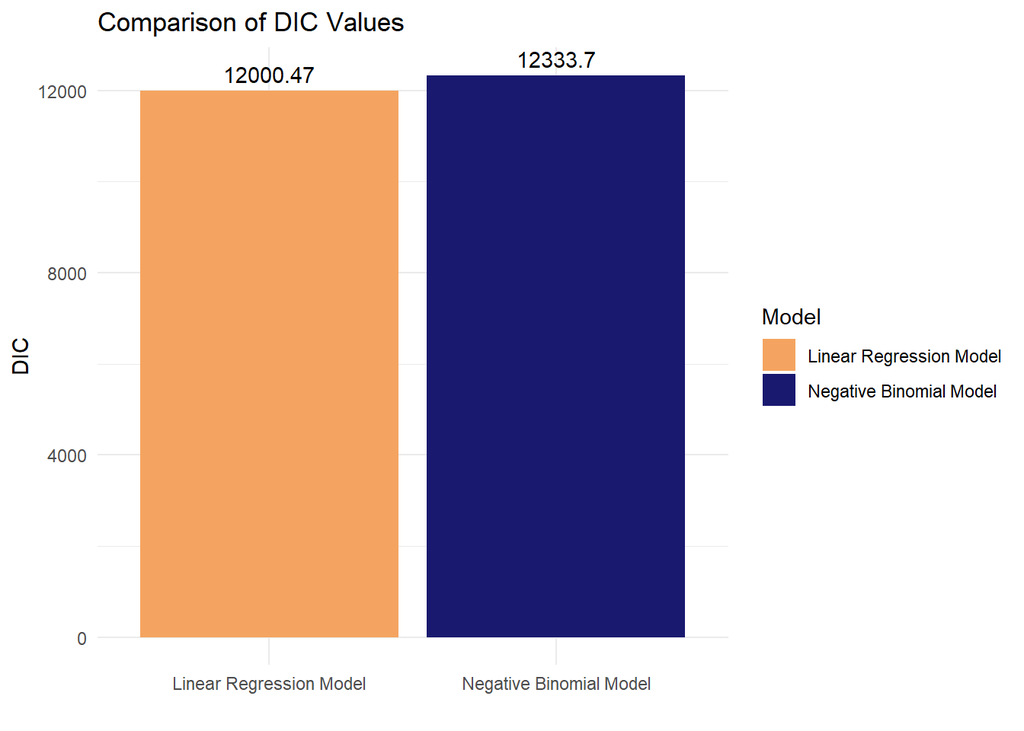

Lower DIC values indicate a better model. Consequently, the **Linear Regression model** appears to be the **most suitable for our data** compared to the Negative Binomial model.

Relying solely on the DIC value is not sufficient to assess the overall goodness of a model. Let’s proceed to analyze the **diagnostics of the Linear Regression model** to gain insights into the reliability of the estimates obtained.

## Diagnostics

### Autocorrelation Function

In a Bayesian analysis, the **Autocorrelation Function (ACF)** measures how correlated the samples of a parameter are at different lags in an MCMC. High autocorrelation indicates that samples are not independent, suggesting potential issues with convergence.

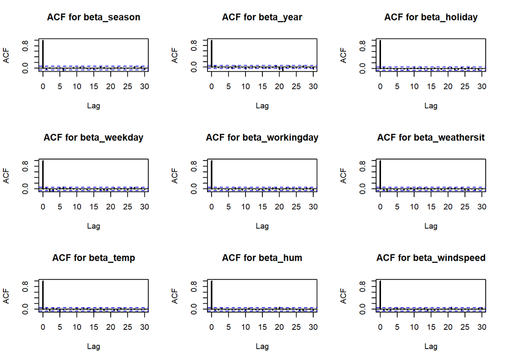

The ACF plots indicate that there is **low autocorrelation** between the sampled values at different lags for any of the parameters. This suggests that these variables are independent of their past values.

### Trace Plots

A traceplot is a key tool in MCMC diagnostics used to assess whether the Markov chains have converged to their stationary distributions and are effectively exploring the parameter space.

The desired result is that the chains within each traceplot show stability and good mixing. **Stability** indicates that the chains have converged to a stationary distribution. **Good mixing** chains will overlap considerably and should not stay in local modes for long.

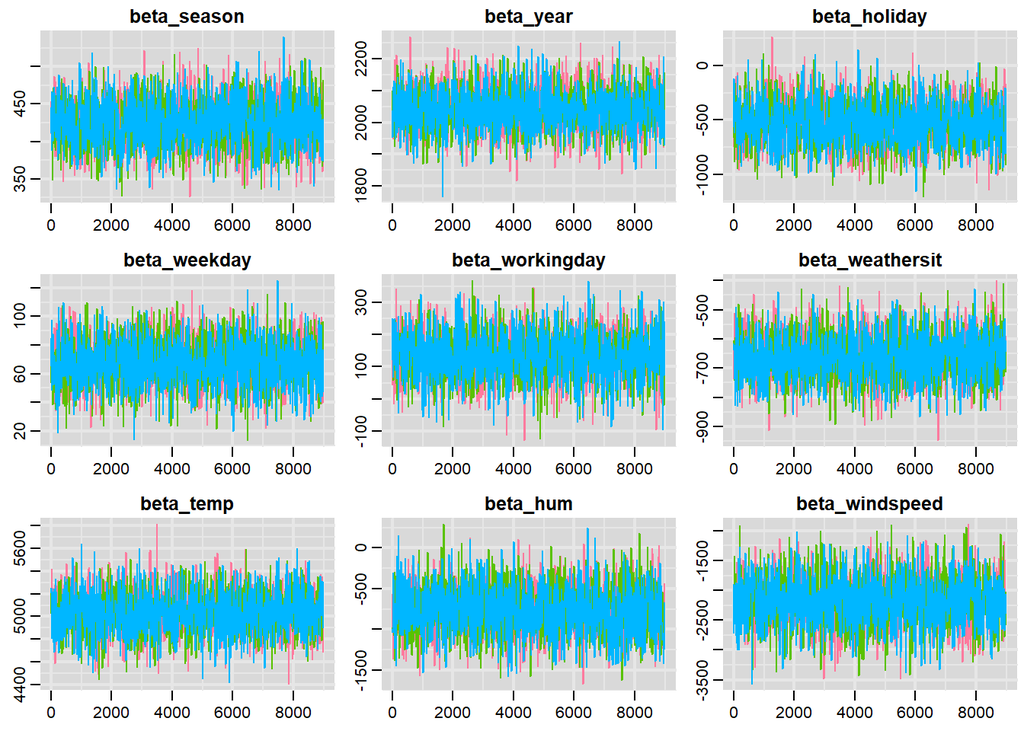

Examining our results, we can assert that all the criteria outlined above have been fully satisfied.

### Density Plots

In MCMC diagnostics, density plots can be used to visualize the distribution of samples from the posterior distribution of parameters. A **well-defined peak** far from zero indicates that the parameter estimate is focused around that value with low uncertainty.

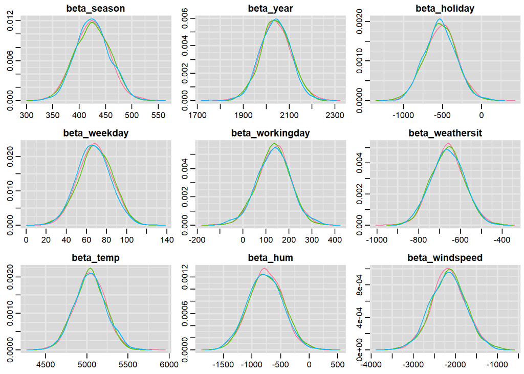

All variables converge to a **normal distribution** with a well-defined peak: this supports the idea that parameter estimates are consistent and focused around true values.

### Raftery & Lewis Test

The Raftery and Lewis diagnostic test is a method used in Bayesian analysis to determine the **number of iterations** (burn-ins M) required in a MCMC simulation to ensure that the results are reliable and that the chain has converged.

```
##
## Quantile (q) = 0.025
## Accuracy (r) = +/- 0.005
## Probability (s) = 0.95
##
## You need a sample size of at least 3746 with these values of q, r and s
```

## Final Considerations

After the analysis, it is evident how crucial it is to investigate the dataset before moving on to the modeling phase. Specifically, the key points of this project are that:

- Registered users show routine use of the service, making it important to encourage the **loyalty of casual users**.
- Since the data show a **seasonal trend**, it could be beneficial to increase bike availability and promote their use during the warmer months.
- **Temperature** (`temp`) is identified as the most significant factor affecting positively the number of bike rentals, while **wind speed** (`windspeed`) is recognized as the primary factor reducing them.
- Employing a model that is overly complex and incorporates redundant variables can result in **multicollinearity issues**. Therefore, it is important to perform feature selection before proceeding to the modeling phase.
- Despite its simplicity, the **Linear Regression model** demonstrated an appropriate fit for this task, achieving satisfactory performance. Linear Regression promotes a linear relationship in statistical models, simplifying the interpretation of complex relationships in the data. Additionally, it helps align the data with a normal distribution, which is a crucial assumption in many statistical analyses.

# References

1.

Kim, J. [Multicollinearity and misleading statistical results](https://doi.org/10.4097/kja.19087). *Korean Journal of Anesthesiology* **72**, 558–569 (2019).